# R Notebook

```r
# Load necessary packages
if (!require(caret)) {
  install.packages("caret")
}
if (!require(cluster)) {
  install.packages("cluster")
}
if (!require(fpc)) {
  install.packages("fpc")
}
if (!require(ggplot2)) {
  install.packages("ggplot2")
}
library(caret)
library(cluster)
library(fpc)
library(ggplot2)
```

Sample of row

```r
dataset = read.csv('GOOG.csv')
```

```r
View(dataset)
```

we removed the attributes (symbol, divCash, splitFactor) as they have one value only so we do not need them

```r
dataset=dataset[,2:12]
```

Convert the date column to a date format

```r
dataset$date <- as.Date(dataset$date, format = "%Y-%m-%d %H:%M:%S")
```

```r
print(dataset)
```

| date | close | high | low | open | volume | adjClose | adjHigh | adjLow | adjOpen | adjVolume |
| --- | --- | --- | --- | --- | --- | --- | --- | --- | --- | --- |
| 2016-06-14 | 718.270 | 722.4700 | 713.1200 | 716.48 | 1306065 | 718.270 | 722.4700 | 713.1200 | 716.48 | 1306065 |
| 2016-06-15 | 718.920 | 722.9800 | 717.3100 | 719.00 | 1214517 | 718.920 | 722.9800 | 717.3100 | 719.00 | 1214517 |
| 2016-06-16 | 710.360 | 716.6500 | 703.2600 | 714.91 | 1982471 | 710.360 | 716.6500 | 703.2600 | 714.91 | 1982471 |
| 2016-06-17 | 691.720 | 708.8200 | 688.4515 | 708.65 | 3402357 | 691.720 | 708.8200 | 688.4515 | 708.65 | 3402357 |
| 2016-06-20 | 693.710 | 702.4800 | 693.4100 | 698.77 | 2082538 | 693.710 | 702.4800 | 693.4100 | 698.77 | 2082538 |
| 2016-06-21 | 695.940 | 702.7700 | 692.0100 | 698.40 | 1465634 | 695.940 | 702.7700 | 692.0100 | 698.40 | 1465634 |
| 2016-06-22 | 697.460 | 700.8600 | 693.0819 | 699.06 | 1184318 | 697.460 | 700.8600 | 693.0819 | 699.06 | 1184318 |
| 2016-06-23 | 701.870 | 701.9500 | 687.0000 | 697.45 | 2171415 | 701.870 | 701.9500 | 687.0000 | 697.45 | 2171415 |
| 2016-06-24 | 675.220 | 689.4000 | 673.4500 | 675.17 | 4449022 | 675.220 | 689.4000 | 673.4500 | 675.17 | 4449022 |
| 2016-06-27 | 668.260 | 672.3000 | 663.2840 | 671.00 | 2641085 | 668.260 | 672.3000 | 663.2840 | 671.00 | 2641085 |

[output cut: 990 more lines]

```r
str(dataset)
```

```
'data.frame':   1258 obs. of  11 variables:
 $ date     : Date, format: "2016-06-14" "2016-06-15" ...
 $ close    : num  718 719 710 692 694 ...
 $ high     : num  722 723 717 709 702 ...
 $ low      : num  713 717 703 688 693 ...
 $ open     : num  716 719 715 709 699 ...
 $ volume   : int  1306065 1214517 1982471 3402357 2082538 1465634 1184318 2171415 4449022 2641085 ...
 $ adjClose : num  718 719 710 692 694 ...
 $ adjHigh  : num  722 723 717 709 702 ...
 $ adjLow   : num  713 717 703 688 693 ...
 $ adjOpen  : num  716 719 715 709 699 ...
 $ adjVolume: int  1306065 1214517 1982471 3402357 2082538 1465634 1184318 2171415 4449022 2641085 ...
```

#statiscal summarise

```r
summary(dataset)
```

```
      date                close             high             low
 Min.   :2016-06-14   Min.   : 668.3   Min.   : 672.3   Min.   : 663.3
 1st Qu.:2017-09-12   1st Qu.: 960.8   1st Qu.: 968.8   1st Qu.: 952.2
 Median :2018-12-11   Median :1132.5   Median :1143.9   Median :1117.9
 Mean   :2018-12-12   Mean   :1216.3   Mean   :1227.4   Mean   :1204.2
 3rd Qu.:2020-03-12   3rd Qu.:1360.6   3rd Qu.:1374.3   3rd Qu.:1348.6
 Max.   :2021-06-11   Max.   :2521.6   Max.   :2527.0   Max.   :2498.3
      open          volume           adjClose         adjHigh
 Min.   : 671   Min.   : 346753   Min.   : 668.3   Min.   : 672.3
 1st Qu.: 959   1st Qu.:1173522   1st Qu.: 960.8   1st Qu.: 968.8
 Median :1131   Median :1412588   Median :1132.5   Median :1143.9
 Mean   :1215   Mean   :1601590   Mean   :1216.3   Mean   :1227.4
 3rd Qu.:1361   3rd Qu.:1812156   3rd Qu.:1360.6   3rd Qu.:1374.3
 Max.   :2525   Max.   :6207027   Max.   :2521.6   Max.   :2527.0
     adjLow          adjOpen       adjVolume
 Min.   : 663.3   Min.   : 671   Min.   : 346753
 1st Qu.: 952.2   1st Qu.: 959   1st Qu.:1173522
 Median :1117.9   Median :1131   Median :1412588
 Mean   :1204.2   Mean   :1215   Mean   :1601590
 3rd Qu.:1348.6   3rd Qu.:1361   3rd Qu.:1812156
 Max.   :2498.3   Max.   :2525   Max.   :6207027
```

#mean of closing price Using the mean closing price can serve as a basic reference point or a simple benchmark for forecasting future stock prices. The mean closing price is the average price at which a stock has closed over a specific period.

```r
mean(dataset$close)
```

```
[1] 1216.317
```

# variance Code

The concept of variance in the context of closing prices for stock prediction serves to quantify the spread or dispersion of the closing prices around their mean or average value. It provides a measure of how much the actual closing prices deviate from the average closing price over a specific period.

```r
var(dataset$close)
```

```
[1] 146944.5
```

#Graphs codes

#Scatter Plot

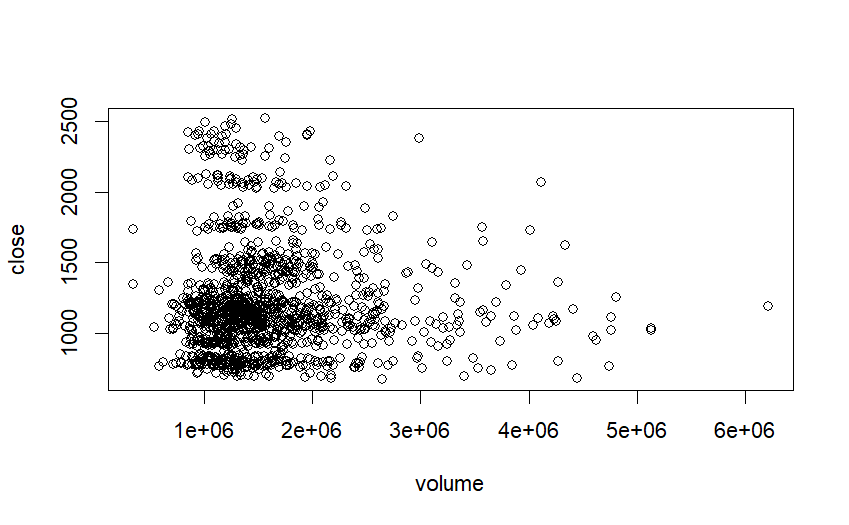

```r
with(dataset, plot(volume, close))
```

#Barplot

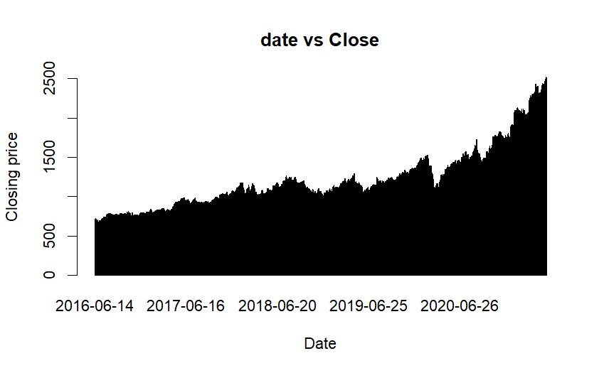

```r
barplot(height = dataset$close, names.arg = dataset$date, xlab = "Date", ylab = "Closing price", main = "date vs Close")
```

#Histogram for Close

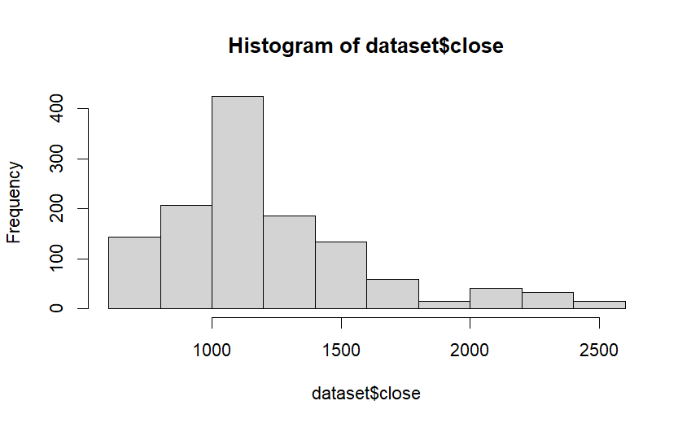

```r
hist(dataset$close)
```

#Data preprocessing

#Data cleaning # to find the total null values in the dataset #Checking NULL, FALSE means no null, TRUE cells means the value of the cell is null

```r
is.na(dataset)
```

```
         date close  high   low  open volume adjClose adjHigh adjLow
   [1,] FALSE FALSE FALSE FALSE FALSE  FALSE    FALSE   FALSE  FALSE
   [2,] FALSE FALSE FALSE FALSE FALSE  FALSE    FALSE   FALSE  FALSE
   [3,] FALSE FALSE FALSE FALSE FALSE  FALSE    FALSE   FALSE  FALSE
   [4,] FALSE FALSE FALSE FALSE FALSE  FALSE    FALSE   FALSE  FALSE
   [5,] FALSE FALSE FALSE FALSE FALSE  FALSE    FALSE   FALSE  FALSE
   [6,] FALSE FALSE FALSE FALSE FALSE  FALSE    FALSE   FALSE  FALSE
   [7,] FALSE FALSE FALSE FALSE FALSE  FALSE    FALSE   FALSE  FALSE
   [8,] FALSE FALSE FALSE FALSE FALSE  FALSE    FALSE   FALSE  FALSE
   [9,] FALSE FALSE FALSE FALSE FALSE  FALSE    FALSE   FALSE  FALSE
  [10,] FALSE FALSE FALSE FALSE FALSE  FALSE    FALSE   FALSE  FALSE
  [11,] FALSE FALSE FALSE FALSE FALSE  FALSE    FALSE   FALSE  FALSE
  [12,] FALSE FALSE FALSE FALSE FALSE  FALSE    FALSE   FALSE  FALSE
  [13,] FALSE FALSE FALSE FALSE FALSE  FALSE    FALSE   FALSE  FALSE
  [14,] FALSE FALSE FALSE FALSE FALSE  FALSE    FALSE   FALSE  FALSE
```

[output cut: 168 more lines]

```r
sum(is.na(dataset))
```

```
[1] 0
```

```r
print("Since there is no NULL values we don't need to remove any rows")
```

```
[1] "Since there is no NULL values we don't need to remove any rows"
```

#Detecting outliers

```r
library(outliers)

OutClose = outlier(dataset$close, logical =TRUE)
sum(OutClose)
```

```
[1] 1
```

```r
Find_outlier = which(OutClose ==TRUE, arr.ind = TRUE)
OutClose
```

```
   [1] FALSE FALSE FALSE FALSE FALSE FALSE FALSE FALSE FALSE FALSE FALSE
  [12] FALSE FALSE FALSE FALSE FALSE FALSE FALSE FALSE FALSE FALSE FALSE
  [23] FALSE FALSE FALSE FALSE FALSE FALSE FALSE FALSE FALSE FALSE FALSE
  [34] FALSE FALSE FALSE FALSE FALSE FALSE FALSE FALSE FALSE FALSE FALSE
  [45] FALSE FALSE FALSE FALSE FALSE FALSE FALSE FALSE FALSE FALSE FALSE
  [56] FALSE FALSE FALSE FALSE FALSE FALSE FALSE FALSE FALSE FALSE FALSE
  [67] FALSE FALSE FALSE FALSE FALSE FALSE FALSE FALSE FALSE FALSE FALSE
  [78] FALSE FALSE FALSE FALSE FALSE FALSE FALSE FALSE FALSE FALSE FALSE
  [89] FALSE FALSE FALSE FALSE FALSE FALSE FALSE FALSE FALSE FALSE FALSE
 [100] FALSE FALSE FALSE FALSE FALSE FALSE FALSE FALSE FALSE FALSE FALSE
 [111] FALSE FALSE FALSE FALSE FALSE FALSE FALSE FALSE FALSE FALSE FALSE
 [122] FALSE FALSE FALSE FALSE FALSE FALSE FALSE FALSE FALSE FALSE FALSE
 [133] FALSE FALSE FALSE FALSE FALSE FALSE FALSE FALSE FALSE FALSE FALSE
 [144] FALSE FALSE FALSE FALSE FALSE FALSE FALSE FALSE FALSE FALSE FALSE
 [155] FALSE FALSE FALSE FALSE FALSE FALSE FALSE FALSE FALSE FALSE FALSE
```

[output cut: 77 more lines]

```r
Find_outlier
```

```
[1] 1257
```

#removing volume’s outlier

```r
OutVolume = outlier(dataset$volume, logical =TRUE)
sum(OutVolume)
```

```
[1] 1
```

```r
Find_outlier = which(OutVolume ==TRUE, arr.ind = TRUE)
OutVolume
```

```
   [1] FALSE FALSE FALSE FALSE FALSE FALSE FALSE FALSE FALSE FALSE FALSE
  [12] FALSE FALSE FALSE FALSE FALSE FALSE FALSE FALSE FALSE FALSE FALSE
  [23] FALSE FALSE FALSE FALSE FALSE FALSE FALSE FALSE FALSE FALSE FALSE
  [34] FALSE FALSE FALSE FALSE FALSE FALSE FALSE FALSE FALSE FALSE FALSE
  [45] FALSE FALSE FALSE FALSE FALSE FALSE FALSE FALSE FALSE FALSE FALSE
  [56] FALSE FALSE FALSE FALSE FALSE FALSE FALSE FALSE FALSE FALSE FALSE
  [67] FALSE FALSE FALSE FALSE FALSE FALSE FALSE FALSE FALSE FALSE FALSE
  [78] FALSE FALSE FALSE FALSE FALSE FALSE FALSE FALSE FALSE FALSE FALSE
  [89] FALSE FALSE FALSE FALSE FALSE FALSE FALSE FALSE FALSE FALSE FALSE
 [100] FALSE FALSE FALSE FALSE FALSE FALSE FALSE FALSE FALSE FALSE FALSE
 [111] FALSE FALSE FALSE FALSE FALSE FALSE FALSE FALSE FALSE FALSE FALSE
 [122] FALSE FALSE FALSE FALSE FALSE FALSE FALSE FALSE FALSE FALSE FALSE
 [133] FALSE FALSE FALSE FALSE FALSE FALSE FALSE FALSE FALSE FALSE FALSE
 [144] FALSE FALSE FALSE FALSE FALSE FALSE FALSE FALSE FALSE FALSE FALSE
 [155] FALSE FALSE FALSE FALSE FALSE FALSE FALSE FALSE FALSE FALSE FALSE
```

[output cut: 77 more lines]

```r
Find_outlier
```

```
[1] 724
```

#Remove outlier

```r
dataset= dataset[-Find_outlier,]
```

#data before preprocessing Before preprocessing the data for stock price prediction, several initial steps are undertaken to understand, review, and prepare the dataset. These steps are crucial for getting an overview of the data and assessing its quality and relevance for the prediction task.

```r
View(dataset)
print(dataset)
```

|  | date | close | high | low | open | volume | adjClose | adjHigh | adjLow | adjOpen | adjVolume |
| --- | --- | --- | --- | --- | --- | --- | --- | --- | --- | --- | --- |
| 1 | 2016-06-14 | 718.270 | 722.4700 | 713.1200 | 716.48 | 1306065 | 718.270 | 722.4700 | 713.1200 | 716.48 | 1306065 |
| 2 | 2016-06-15 | 718.920 | 722.9800 | 717.3100 | 719.00 | 1214517 | 718.920 | 722.9800 | 717.3100 | 719.00 | 1214517 |
| 3 | 2016-06-16 | 710.360 | 716.6500 | 703.2600 | 714.91 | 1982471 | 710.360 | 716.6500 | 703.2600 | 714.91 | 1982471 |
| 4 | 2016-06-17 | 691.720 | 708.8200 | 688.4515 | 708.65 | 3402357 | 691.720 | 708.8200 | 688.4515 | 708.65 | 3402357 |
| 5 | 2016-06-20 | 693.710 | 702.4800 | 693.4100 | 698.77 | 2082538 | 693.710 | 702.4800 | 693.4100 | 698.77 | 2082538 |
| 6 | 2016-06-21 | 695.940 | 702.7700 | 692.0100 | 698.40 | 1465634 | 695.940 | 702.7700 | 692.0100 | 698.40 | 1465634 |
| 7 | 2016-06-22 | 697.460 | 700.8600 | 693.0819 | 699.06 | 1184318 | 697.460 | 700.8600 | 693.0819 | 699.06 | 1184318 |
| 8 | 2016-06-23 | 701.870 | 701.9500 | 687.0000 | 697.45 | 2171415 | 701.870 | 701.9500 | 687.0000 | 697.45 | 2171415 |
| 9 | 2016-06-24 | 675.220 | 689.4000 | 673.4500 | 675.17 | 4449022 | 675.220 | 689.4000 | 673.4500 | 675.17 | 4449022 |
| 10 | 2016-06-27 | 668.260 | 672.3000 | 663.2840 | 671.00 | 2641085 | 668.260 | 672.3000 | 663.2840 | 671.00 | 2641085 |

[output cut: 990 more lines]

#transformation

#Feature selection ,Remove Redundant Features

```r
# load the library
library(mlbench)
library(caret)
library(ggplot2)
library(lattice)

# calculate correlation matrix
correlationMatrix <- cor(dataset[,2:11])

# summarize the correlation matrix
print(correlationMatrix)
```

```
                close        high         low        open      volume
close      1.00000000  0.99952831  0.99958610  0.99908254 -0.02564218
high       0.99952831  1.00000000  0.99935402  0.99957474 -0.01221447
low        0.99958610  0.99935402  1.00000000  0.99949862 -0.03540047
open       0.99908254  0.99957474  0.99949862  1.00000000 -0.02133976
volume    -0.02564218 -0.01221447 -0.03540047 -0.02133976  1.00000000
adjClose   1.00000000  0.99952831  0.99958610  0.99908254 -0.02564218
adjHigh    0.99952831  1.00000000  0.99935402  0.99957474 -0.01221447
adjLow     0.99958610  0.99935402  1.00000000  0.99949862 -0.03540047
adjOpen    0.99908254  0.99957474  0.99949862  1.00000000 -0.02133976
adjVolume -0.02564218 -0.01221447 -0.03540047 -0.02133976  1.00000000
             adjClose     adjHigh      adjLow     adjOpen   adjVolume
close      1.00000000  0.99952831  0.99958610  0.99908254 -0.02564218
high       0.99952831  1.00000000  0.99935402  0.99957474 -0.01221447
low        0.99958610  0.99935402  1.00000000  0.99949862 -0.03540047
open       0.99908254  0.99957474  0.99949862  1.00000000 -0.02133976
volume    -0.02564218 -0.01221447 -0.03540047 -0.02133976  1.00000000
adjClose   1.00000000  0.99952831  0.99958610  0.99908254 -0.02564218
adjHigh    0.99952831  1.00000000  0.99935402  0.99957474 -0.01221447
adjLow     0.99958610  0.99935402  1.00000000  0.99949862 -0.03540047
adjOpen    0.99908254  0.99957474  0.99949862  1.00000000 -0.02133976
adjVolume -0.02564218 -0.01221447 -0.03540047 -0.02133976  1.00000000
```

```r
# find attributes that are highly corrected (ideally >0.75)
highlyCorrelated <- findCorrelation(correlationMatrix, cutoff=0.5 )

# print indexes of highly correlated attributes
print(highlyCorrelated)
```

```
[1] 8 3 1 6 4 9 2 5
```

#Normalization normalization was performed to ensure consistent scaling of the data. The normalization technique applied was the max-min normalization. This technique rescales the values of specific attributes within a defined range between 0 and 1.

We can use the normalized dataset provides a more uniform and comparable representation of the attributes, enabling accurate analysis and modeling for stock predaction with result as shown.

```r
normalize <- function(x) {return ((x - min(x)) / (max(x) - min(x)))}
dataWithoutNormalization <- dataset
dataset$close<-normalize(dataWithoutNormalization$close)
dataset$volume<-normalize(dataWithoutNormalization$volume)
dataset$open<-normalize(dataWithoutNormalization$open)
dataset$low <-normalize(dataWithoutNormalization$low)
dataset$high <-normalize(dataWithoutNormalization$high)
```

#Discretization we used the Discretization technique on our class label “close” to simplify it as it has a large continuous values, we made them fall into intervals, to make it easier to analyze

```r
dataset$close <- ifelse(dataset$close <= 0.2957251 , "low","High")
print(dataset)
```

|  | date | close | high | low | open | volume | adjClose | adjHigh | adjLow | adjOpen | adjVolume |
| --- | --- | --- | --- | --- | --- | --- | --- | --- | --- | --- | --- |
| 1 | 2016-06-14 | low | 0.027050343 | 0.027158494 | 0.024531803 | 0.2005325030 | 718.270 | 722.4700 | 713.1200 | 716.48 | 1306065 |
| 2 | 2016-06-15 | low | 0.027325321 | 0.029441866 | 0.025891085 | 0.1813955073 | 718.920 | 722.9800 | 717.3100 | 719.00 | 1214517 |
| 3 | 2016-06-16 | low | 0.023912352 | 0.021785215 | 0.023684949 | 0.3419269484 | 710.360 | 716.6500 | 703.2600 | 714.91 | 1982471 |
| 4 | 2016-06-17 | low | 0.019690622 | 0.013715214 | 0.020308320 | 0.6387368429 | 691.720 | 708.8200 | 688.4515 | 708.65 | 3402357 |
| 5 | 2016-06-20 | low | 0.016272261 | 0.016417385 | 0.014979071 | 0.3628447374 | 693.710 | 702.4800 | 693.4100 | 698.77 | 2082538 |
| 6 | 2016-06-21 | low | 0.016428621 | 0.015654445 | 0.014779494 | 0.2338884612 | 695.940 | 702.7700 | 692.0100 | 698.40 | 1465634 |
| 7 | 2016-06-22 | low | 0.015398800 | 0.016238585 | 0.015135497 | 0.1750827738 | 697.460 | 700.8600 | 693.0819 | 699.06 | 1184318 |
| 8 | 2016-06-23 | low | 0.015986499 | 0.012924208 | 0.014267067 | 0.3814233930 | 701.870 | 701.9500 | 687.0000 | 697.45 | 2171415 |
| 9 | 2016-06-24 | low | 0.009219870 | 0.005540036 | 0.002249288 | 0.8575294278 | 675.220 | 689.4000 | 673.4500 | 675.17 | 4449022 |
| 10 | 2016-06-27 | low | 0.000000000 | 0.000000000 | 0.000000000 | 0.4796021926 | 668.260 | 672.3000 | 663.2840 | 671.00 | 2641085 |

[output cut: 990 more lines]

we discretized it into two categories (low, high) based on the maen, low meaning it is less than the mean of the close , and high meaning it is equal to or higher than the mean.

#Encoding We encoded close data into factors, which would help the model read this data easily

```r
dataset$close <- factor(dataset$close,levels = c("low", "High"), labels = c("1", "2"))

print(dataset)
```

|  | date | close | high | low | open | volume | adjClose | adjHigh | adjLow | adjOpen | adjVolume |
| --- | --- | --- | --- | --- | --- | --- | --- | --- | --- | --- | --- |
| 1 | 2016-06-14 | 1 | 0.027050343 | 0.027158494 | 0.024531803 | 0.2005325030 | 718.270 | 722.4700 | 713.1200 | 716.48 | 1306065 |
| 2 | 2016-06-15 | 1 | 0.027325321 | 0.029441866 | 0.025891085 | 0.1813955073 | 718.920 | 722.9800 | 717.3100 | 719.00 | 1214517 |
| 3 | 2016-06-16 | 1 | 0.023912352 | 0.021785215 | 0.023684949 | 0.3419269484 | 710.360 | 716.6500 | 703.2600 | 714.91 | 1982471 |
| 4 | 2016-06-17 | 1 | 0.019690622 | 0.013715214 | 0.020308320 | 0.6387368429 | 691.720 | 708.8200 | 688.4515 | 708.65 | 3402357 |
| 5 | 2016-06-20 | 1 | 0.016272261 | 0.016417385 | 0.014979071 | 0.3628447374 | 693.710 | 702.4800 | 693.4100 | 698.77 | 2082538 |
| 6 | 2016-06-21 | 1 | 0.016428621 | 0.015654445 | 0.014779494 | 0.2338884612 | 695.940 | 702.7700 | 692.0100 | 698.40 | 1465634 |
| 7 | 2016-06-22 | 1 | 0.015398800 | 0.016238585 | 0.015135497 | 0.1750827738 | 697.460 | 700.8600 | 693.0819 | 699.06 | 1184318 |
| 8 | 2016-06-23 | 1 | 0.015986499 | 0.012924208 | 0.014267067 | 0.3814233930 | 701.870 | 701.9500 | 687.0000 | 697.45 | 2171415 |
| 9 | 2016-06-24 | 1 | 0.009219870 | 0.005540036 | 0.002249288 | 0.8575294278 | 675.220 | 689.4000 | 673.4500 | 675.17 | 4449022 |
| 10 | 2016-06-27 | 1 | 0.000000000 | 0.000000000 | 0.000000000 | 0.4796021926 | 668.260 | 672.3000 | 663.2840 | 671.00 | 2641085 |

[output cut: 990 more lines]

#summary after preprocessing after preprocessing the data for stock price prediction, several steps are taken to refine, clean, and prepare the data for analysis and modeling. These preprocessing steps aim to enhance the quality and reliability of the data for more accurate stock price prediction.

```r
print(dataset)
```

|  | date | close | high | low | open | volume | adjClose | adjHigh | adjLow | adjOpen | adjVolume |
| --- | --- | --- | --- | --- | --- | --- | --- | --- | --- | --- | --- |
| 1 | 2016-06-14 | 1 | 0.027050343 | 0.027158494 | 0.024531803 | 0.2005325030 | 718.270 | 722.4700 | 713.1200 | 716.48 | 1306065 |
| 2 | 2016-06-15 | 1 | 0.027325321 | 0.029441866 | 0.025891085 | 0.1813955073 | 718.920 | 722.9800 | 717.3100 | 719.00 | 1214517 |
| 3 | 2016-06-16 | 1 | 0.023912352 | 0.021785215 | 0.023684949 | 0.3419269484 | 710.360 | 716.6500 | 703.2600 | 714.91 | 1982471 |
| 4 | 2016-06-17 | 1 | 0.019690622 | 0.013715214 | 0.020308320 | 0.6387368429 | 691.720 | 708.8200 | 688.4515 | 708.65 | 3402357 |
| 5 | 2016-06-20 | 1 | 0.016272261 | 0.016417385 | 0.014979071 | 0.3628447374 | 693.710 | 702.4800 | 693.4100 | 698.77 | 2082538 |
| 6 | 2016-06-21 | 1 | 0.016428621 | 0.015654445 | 0.014779494 | 0.2338884612 | 695.940 | 702.7700 | 692.0100 | 698.40 | 1465634 |
| 7 | 2016-06-22 | 1 | 0.015398800 | 0.016238585 | 0.015135497 | 0.1750827738 | 697.460 | 700.8600 | 693.0819 | 699.06 | 1184318 |
| 8 | 2016-06-23 | 1 | 0.015986499 | 0.012924208 | 0.014267067 | 0.3814233930 | 701.870 | 701.9500 | 687.0000 | 697.45 | 2171415 |
| 9 | 2016-06-24 | 1 | 0.009219870 | 0.005540036 | 0.002249288 | 0.8575294278 | 675.220 | 689.4000 | 673.4500 | 675.17 | 4449022 |
| 10 | 2016-06-27 | 1 | 0.000000000 | 0.000000000 | 0.000000000 | 0.4796021926 | 668.260 | 672.3000 | 663.2840 | 671.00 | 2641085 |

[output cut: 990 more lines]

```r
View(dataset)
```

Feature selection

Feature selection is a process of selecting a subset of relevant features (or attributes) from the original set of features in a dataset. The goal of feature selection is to choose the most relevant and important features, thereby reducing dimensionality, and improving model performance.

#Feature selection ,Feature selection using Recursive Feature Elimination or RFE

```r
    library(mlbench)
library(caret)

# define the control using a random forest selection function
# number=12 means the length of the list
control <- rfeControl(functions=rfFuncs, method="cv", number=11)
# run the RFE algorithm from column 1 to 11
results <- rfe(dataset[,1:10],dataset[,11], sizes=c(1:10), rfeControl=control)
```

# summarize the results

```r
print(results)
```

```
Recursive feature selection

Outer resampling method: Cross-Validated (11 fold)

Resampling performance over subset size:
```

|  | Variables | RMSE | Rsquared | MAE | RMSESD | RsquaredSD | MAESD | Selected |
| --- | --- | --- | --- | --- | --- | --- | --- | --- |
| 1 | 1 | 11236 | 0.9996 | 2854 | 13696 | 0.0008741 | 1896 | * |
| 2 | 2 | 57146 | 0.9943 | 22945 | 28924 | 0.0039055 | 6071 |  |
| 3 | 3 | 116338 | 0.9778 | 52258 | 40023 | 0.0101736 | 9903 |  |
| 4 | 4 | 166276 | 0.9556 | 82924 | 46254 | 0.0179623 | 13783 |  |
| 5 | 5 | 204425 | 0.9354 | 108707 | 50868 | 0.0224388 | 15715 |  |
| 6 | 6 | 117833 | 0.9771 | 52196 | 41463 | 0.0114512 | 11907 |  |
| 7 | 7 | 145544 | 0.9653 | 68553 | 47484 | 0.0164013 | 12784 |  |
| 8 | 8 | 163356 | 0.9570 | 80607 | 48045 | 0.0181867 | 13484 |  |
| 9 | 9 | 120807 | 0.9758 | 53556 | 43003 | 0.0128145 | 11629 |  |
| 10 | 10 | 134732 | 0.9703 | 62447 | 42297 | 0.0139854 | 12299 |  |

```
The top 1 variables (out of 1):
   volume
```

# list the chosen features

```r
predictors(results)
```

```
[1] "volume"
```

# plot the results

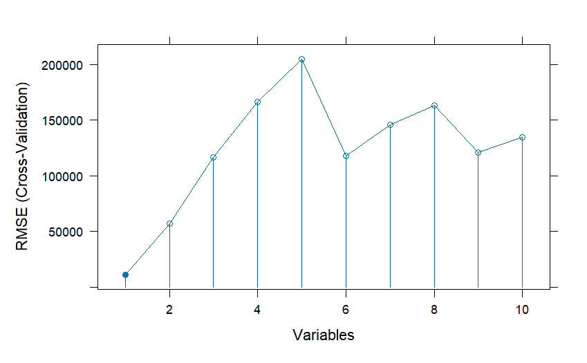

```r
plot(results, type=c("h", "o"))
```

Data Mining Task

We did both supervised and unsupervised learning techniques on our dataset (Google stock prediction), which involves classification and clustering methods, for classification we did a partitioning method called the train-test split, which splits the dataset into two subsets of different ratios, and we implemented three algorithms to form 9 different decision trees.

#Classification:

1. Dividing the dataset:

we divided our dataset into two divisions for each split:

first one 70-30, which means Training(70%) and Testing(30%):

```r
# a fixed random seed to make results reproducible
set.seed(1234)

# 1.Split the datasets into two subsets: Training(70%) and Testing(30%):
ind1 <- sample(2, nrow(dataset), replace=TRUE, prob=c( 0.70, 0.30))
trainData  <- dataset[ind1==1,]
testData <- dataset[ind1==2,]
```

# 2.Determine the predictor attributes and the class label attribute.( the formula):

```r
library(party)
#myFormula
myFormula <- close ~volume+open+high+low
```

# 3.Build a decision tree using Information gain:

Information gain is a concept used in the field of machine learning and decision tree algorithms. It is a measure of the effectiveness of a particular attribute in classifying data. In the context of decision trees, information gain helps determine the order in which attributes are chosen for splitting the data.

```r
dataset_ctree <- ctree(myFormula, data=trainData)
table(predict(dataset_ctree), trainData$close)
```

```
      1   2
  1 562   3
  2   1 320
```

```r
# 4.Print and plot the tree:

print(dataset_ctree)
```

```
     Conditional inference tree with 3 terminal nodes

Response:  close
Inputs:  volume, open, high, low
Number of observations:  886

1) high <= 0.2959956; criterion = 1, statistic = 533.419
  2)*  weights = 556
1) high > 0.2959956
  3) low <= 0.2956045; criterion = 0.988, statistic = 8.834
    4)*  weights = 9
  3) low > 0.2956045
    5)*  weights = 321
```

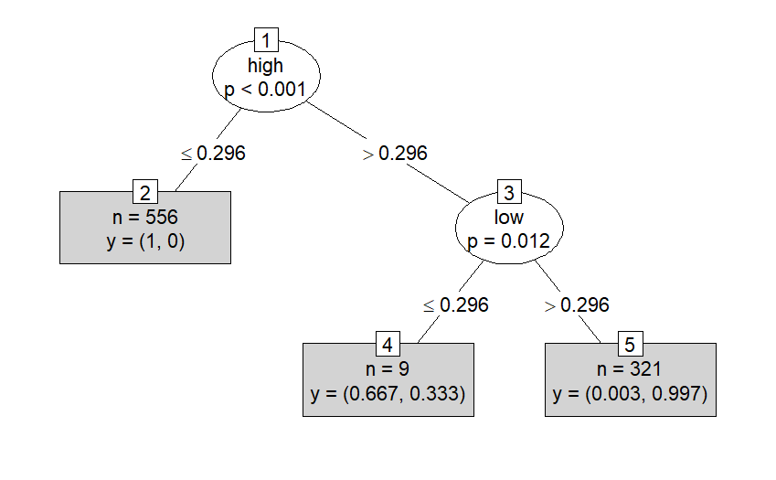

```r
plot(dataset_ctree, type="simple")
```

```r
# 5.Use the constructed model to predict the class labels of test data:
testPred <- predict(dataset_ctree, newdata = testData)
result<-table(testPred, testData$close)
result
```

```
testPred   1   2
       1 243   4
       2   1 123
```

```r
# Evaluate the model and create confusion matrix
install.packages("caret")
```

```
Error in install.packages : Updating loaded packages
```

```r
install.packages('e1071', dependencies=TRUE)
```

```
Error in install.packages : Updating loaded packages
```

```r
library(e1071)
library(caret)

co_result <- confusionMatrix(result)

print(co_result)
```

```
Confusion Matrix and Statistics


testPred   1   2
       1 243   4
       2   1 123

               Accuracy : 0.9865
                 95% CI : (0.9688, 0.9956)
    No Information Rate : 0.6577
    P-Value [Acc > NIR] : <2e-16

                  Kappa : 0.9699

 Mcnemar's Test P-Value : 0.3711

            Sensitivity : 0.9959
            Specificity : 0.9685
         Pos Pred Value : 0.9838
         Neg Pred Value : 0.9919
             Prevalence : 0.6577
         Detection Rate : 0.6550
   Detection Prevalence : 0.6658
      Balanced Accuracy : 0.9822

       'Positive' Class : 1
```

```r
sensitivity(as.table(co_result))
```

```
[1] 0.9959016
```

```r
specificity(as.table(co_result))
```

```
[1] 0.9685039
```

```r
acc <- co_result$overall["Accuracy"]
acc
```

```
 Accuracy
0.9865229
```

2. Building the Tree using Gini Index(CART)

The Gini Index is another criterion used in decision tree algorithms, particularly in the context of the Classification and Regression Trees (CART) algorithm. Like information gain, the Gini Index is used to evaluate the impurity or homogeneity of a dataset.

The Gini Index for a specific attribute measures the probability of incorrectly classifying a randomly chosen element in the dataset. A lower Gini Index indicates a purer or more homogeneous set. In the context of decision trees, the attribute with the lowest Gini Index is chosen as the split attribute.

```r
# For decision tree model
install.packages("rpart")
```

```
Error in install.packages : Updating loaded packages
```

```r
library(rpart)
# For data visualization
library(rpart.plot)

dataset.cart <- rpart(myFormula, data = trainData, method = "class", parms = list(split = "gini"))
```

# Visualizing the unpruned tree

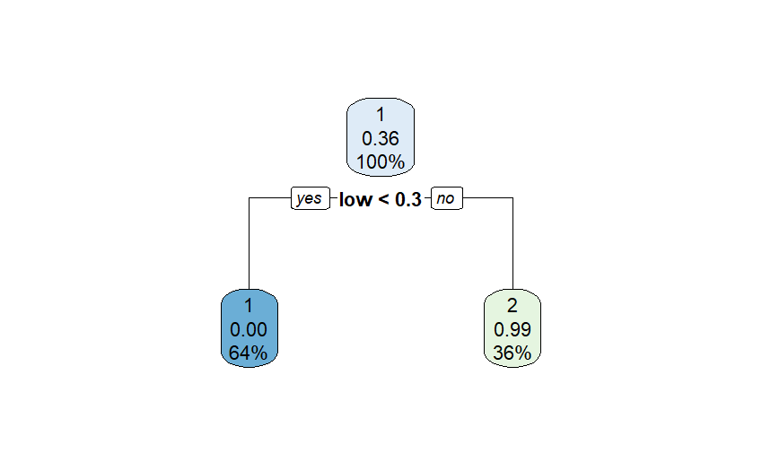

```r
library(rpart.plot)
rpart.plot(dataset.cart)
```

# Checking the order of variable importance

```r
dataset.cart$variable.importance
```

```
       low       high       open     volume
402.533334 396.302168 396.302168   2.492466
```

```r
pred.tree = predict(dataset.cart, testData, type = "class")

table(pred.tree,testData$close)
```

```
pred.tree   1   2
        1 243   3
        2   1 124
```

```r
# 5.Use the constructed model to predict the class labels of test data:
testPred <- predict(dataset_ctree, newdata = testData)
result<-table(testPred, testData$close)
result
```

```
testPred   1   2
       1 243   4
       2   1 123
```

```r
# Evaluate the model and create confusion matrix
install.packages("caret")
```

```
Error in install.packages : Updating loaded packages
```

```r
install.packages('e1071', dependencies=TRUE)
```

```
Error in install.packages : Updating loaded packages
```

```r
library(e1071)
library(caret)

co_result <- confusionMatrix(result)

print(co_result)
```

```
Confusion Matrix and Statistics


testPred   1   2
       1 243   4
       2   1 123

               Accuracy : 0.9865
                 95% CI : (0.9688, 0.9956)
    No Information Rate : 0.6577
    P-Value [Acc > NIR] : <2e-16

                  Kappa : 0.9699

 Mcnemar's Test P-Value : 0.3711

            Sensitivity : 0.9959
            Specificity : 0.9685
         Pos Pred Value : 0.9838
         Neg Pred Value : 0.9919
             Prevalence : 0.6577
         Detection Rate : 0.6550
   Detection Prevalence : 0.6658
      Balanced Accuracy : 0.9822

       'Positive' Class : 1
```

```r
sensitivity(as.table(co_result))
```

```
[1] 0.9959016
```

```r
specificity(as.table(co_result))
```

```
[1] 0.9685039
```

```r
acc <- co_result$overall["Accuracy"]
acc
```

```
 Accuracy
0.9865229
```

3. Building the Tree using Gain ratio(C5)

The Gain Ratio is used to select the attribute that maximizes the Information Gain while avoiding the bias towards attributes with many values. It provides a more balanced measure for attribute selection in decision tree construction.

While Information Gain simply measures the reduction in entropy or uncertainty, Gain Ratio takes into account the intrinsic information of an attribute. It aims to penalize attributes that may have a large number of values, potentially leading to overfitting.

```r
install.packages("caret")
```

```
Error in install.packages : Updating loaded packages
```

```r
install.packages("C50")
```

```
Error in install.packages : Updating loaded packages
```

```r
install.packages("printr")
```

```
Error in install.packages : Updating loaded packages
```

```r
library(C50)
library(printr)
library(caret)
#train using the trainData and create the c5.0 gain ratio tree
CloseTree <- C5.0(myFormula, data=trainData)
summary(CloseTree)
```

```
Call:
C5.0.formula(formula = myFormula, data = trainData)


C5.0 [Release 2.07 GPL Edition]     Mon Nov 13 20:59:31 2023
-------------------------------

Class specified by attribute `outcome'

Read 886 cases (5 attributes) from undefined.data

Decision tree:

low <= 0.2952285: 1 (563/2)
low > 0.2952285: 2 (323/2)


Evaluation on training data (886 cases):

        Decision Tree
      ----------------
      Size      Errors

         2    4( 0.5%)   <<


       (a)   (b)    <-classified as
      ----  ----
       561     2    (a): class 1
         2   321    (b): class 2


    Attribute usage:

    100.00% low


Time: 0.0 secs
```

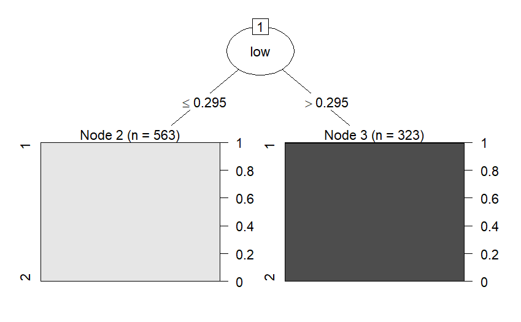

```r
plot(CloseTree)
```

second one 60-40, which means Training(60%) and Testing(40%):

```r
# a fixed random seed to make results reproducible
set.seed(1234)

# 1.Split the datasets into two subsets: Training(60%) and Testing(40%):
ind1 <- sample(2, nrow(dataset), replace=TRUE, prob=c(0.60 , 0.40))
trainData  <- dataset[ind1==1,]
testData <- dataset[ind1==2,]
```

# 2.Determine the predictor attributes and the class label attribute.( the formula):

```r
library(party)
#myFormula
myFormula <- close ~volume+open+high+low
```

# 3.Build a decision tree using training set and check the Prediction:

```r
dataset_ctree <- ctree(myFormula, data=trainData)
table(predict(dataset_ctree), trainData$close)
```

```
      1   2
  1 478   2
  2   1 275
```

```r
# 4.Print and plot the tree:

print(dataset_ctree)
```

```
     Conditional inference tree with 3 terminal nodes

Response:  close
Inputs:  volume, open, high, low
Number of observations:  756

1) high <= 0.2959956; criterion = 1, statistic = 458.97
  2)*  weights = 473
1) high > 0.2959956
  3) low <= 0.2956045; criterion = 0.977, statistic = 7.622
    4)*  weights = 7
  3) low > 0.2956045
    5)*  weights = 276
```

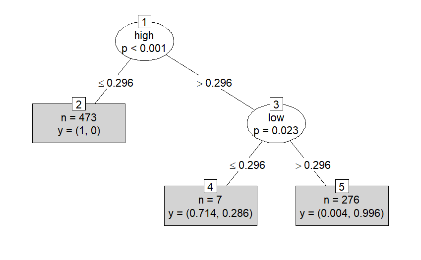

```r
plot(dataset_ctree, type="simple")
```

```r
# 5.Use the constructed model to predict the class labels of test data:
testPred <- predict(dataset_ctree, newdata = testData)
result<-table(testPred, testData$close)
result
```

```
testPred   1   2
       1 327   5
       2   1 168
```

```r
# Evaluate the model and create confusion matrix
install.packages("caret")
```

```
Error in install.packages : Updating loaded packages
```

```r
install.packages('e1071', dependencies=TRUE)
```

```
Error in install.packages : Updating loaded packages
```

```r
library(e1071)
library(caret)

co_result <- confusionMatrix(result)

print(co_result)
```

```
Confusion Matrix and Statistics


testPred   1   2
       1 327   5
       2   1 168

               Accuracy : 0.988
                 95% CI : (0.9741, 0.9956)
    No Information Rate : 0.6547
    P-Value [Acc > NIR] : <2e-16

                  Kappa : 0.9734

 Mcnemar's Test P-Value : 0.2207

            Sensitivity : 0.9970
            Specificity : 0.9711
         Pos Pred Value : 0.9849
         Neg Pred Value : 0.9941
             Prevalence : 0.6547
         Detection Rate : 0.6527
   Detection Prevalence : 0.6627
      Balanced Accuracy : 0.9840

       'Positive' Class : 1
```

```r
sensitivity(as.table(co_result))
```

```
[1] 0.9969512
```

```r
specificity(as.table(co_result))
```

```
[1] 0.9710983
```

```r
acc <- co_result$overall["Accuracy"]
acc
```

```
Accuracy
0.988024
```

2. Building the Tree using Gini Index(CART)

```r
# For decision tree model
install.packages("rpart")
```

```
Error in install.packages : Updating loaded packages
```

```r
library(rpart)
# For data visualization
library(rpart.plot)

dataset.cart <- rpart(myFormula, data = trainData, method = "class", parms = list(split = "gini"))
```

# Visualizing the unpruned tree

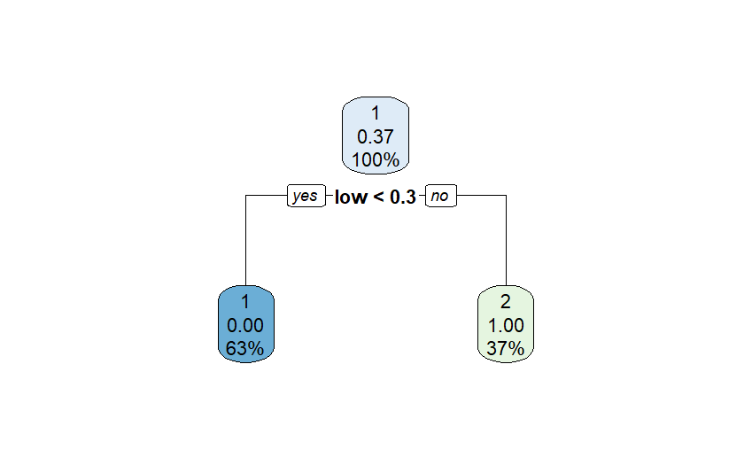

```r
rpart.plot(dataset.cart)
```

# Checking the order of variable importance

```r
dataset.cart$variable.importance
```

```
       low       open       high     volume
345.037141 340.036602 337.536333   1.250135
```

```r
pred.tree = predict(dataset.cart, testData, type = "class")

table(pred.tree,testData$close)
```

```
pred.tree   1   2
        1 327   5
        2   1 168
```

```r
# 5.Use the constructed model to predict the class labels of test data:
testPred <- predict(dataset_ctree, newdata = testData)
result<-table(testPred, testData$close)
result
```

```
testPred   1   2
       1 327   5
       2   1 168
```

```r
# Evaluate the model and create confusion matrix
install.packages("caret")
```

```
Error in install.packages : Updating loaded packages
```

```r
install.packages('e1071', dependencies=TRUE)
```

```
Error in install.packages : Updating loaded packages
```

```r
library(e1071)
library(caret)

co_result <- confusionMatrix(result)

print(co_result)
```

```
Confusion Matrix and Statistics


testPred   1   2
       1 327   5
       2   1 168

               Accuracy : 0.988
                 95% CI : (0.9741, 0.9956)
    No Information Rate : 0.6547
    P-Value [Acc > NIR] : <2e-16

                  Kappa : 0.9734

 Mcnemar's Test P-Value : 0.2207

            Sensitivity : 0.9970
            Specificity : 0.9711
         Pos Pred Value : 0.9849
         Neg Pred Value : 0.9941
             Prevalence : 0.6547
         Detection Rate : 0.6527
   Detection Prevalence : 0.6627
      Balanced Accuracy : 0.9840

       'Positive' Class : 1
```

```r
sensitivity(as.table(co_result))
```

```
[1] 0.9969512
```

```r
specificity(as.table(co_result))
```

```
[1] 0.9710983
```

```r
acc <- co_result$overall["Accuracy"]
acc
```

```
Accuracy
0.988024
```

3. Building the Tree using Gain ratio(C5)

```r
install.packages("caret")
```

```
Error in install.packages : Updating loaded packages
```

```r
install.packages("C50")
```

```
Error in install.packages : Updating loaded packages
```

```r
install.packages("printr")
```

```
Error in install.packages : Updating loaded packages
```

```r
library(C50)
library(printr)
library(caret)
#train using the trainData and create the c5.0 gain ratio tree
CloseTree <- C5.0(myFormula, data=trainData)
summary(CloseTree)
```

```
Call:
C5.0.formula(formula = myFormula, data = trainData)


C5.0 [Release 2.07 GPL Edition]     Mon Nov 13 20:59:35 2023
-------------------------------

Class specified by attribute `outcome'

Read 756 cases (5 attributes) from undefined.data

Decision tree:

low <= 0.2956045: 1 (480/2)
low > 0.2956045: 2 (276/1)


Evaluation on training data (756 cases):

        Decision Tree
      ----------------
      Size      Errors

         2    3( 0.4%)   <<


       (a)   (b)    <-classified as
      ----  ----
       478     1    (a): class 1
         2   275    (b): class 2


    Attribute usage:

    100.00% low


Time: 0.0 secs
```

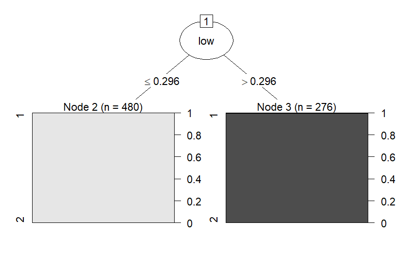

```r
plot(CloseTree)
```

Third one 80-20, which means Training(80%) and Testing(20%):

```r
# a fixed random seed to make results reproducible
set.seed(1234)

# 1.Split the datasets into two subsets: Training(80%) and Testing(20%):
ind1 <- sample(2, nrow(dataset), replace=TRUE, prob=c(0.80 , 0.20))
trainData  <- dataset[ind1==1,]
testData <- dataset[ind1==2,]
```

# 2.Determine the predictor attributes and the class label attribute.( the formula):

```r
library(party)
#myFormula
myFormula <- close ~volume+open+high+low
```

# 3.Build a decision tree using training set and check the Prediction:

```r
dataset_ctree <- ctree(myFormula, data=trainData)
table(predict(dataset_ctree), trainData$close)
```

```
      1   2
  1 638   4
  2   1 359
```

```r
# 4.Print and plot the tree:

print(dataset_ctree)
```

```
     Conditional inference tree with 3 terminal nodes

Response:  close
Inputs:  volume, open, high, low
Number of observations:  1002

1) high <= 0.2959956; criterion = 1, statistic = 604.29
  2)*  weights = 632
1) high > 0.2959956
  3) low <= 0.2956045; criterion = 0.989, statistic = 8.888
    4)*  weights = 10
  3) low > 0.2956045
    5)*  weights = 360
```

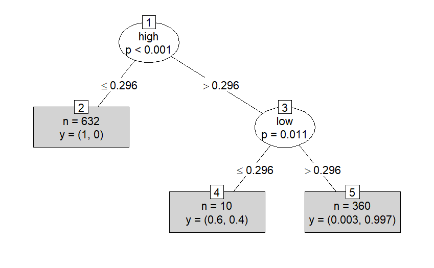

```r
plot(dataset_ctree, type="simple")
```

```r
# 5.Use the constructed model to predict the class labels of test data:
testPred <- predict(dataset_ctree, newdata = testData)
result<-table(testPred, testData$close)
result
```

```
testPred   1   2
       1 167   3
       2   1  84
```

```r
# Evaluate the model and create confusion matrix
install.packages("caret")
```

```
Error in install.packages : Updating loaded packages
```

```r
install.packages('e1071', dependencies=TRUE)
```

```
Error in install.packages : Updating loaded packages
```

```r
library(e1071)
library(caret)

co_result <- confusionMatrix(result)

print(co_result)
```

```
Confusion Matrix and Statistics


testPred   1   2
       1 167   3
       2   1  84

               Accuracy : 0.9843
                 95% CI : (0.9603, 0.9957)
    No Information Rate : 0.6588
    P-Value [Acc > NIR] : <2e-16

                  Kappa : 0.9649

 Mcnemar's Test P-Value : 0.6171

            Sensitivity : 0.9940
            Specificity : 0.9655
         Pos Pred Value : 0.9824
         Neg Pred Value : 0.9882
             Prevalence : 0.6588
         Detection Rate : 0.6549
   Detection Prevalence : 0.6667
      Balanced Accuracy : 0.9798

       'Positive' Class : 1
```

```r
sensitivity(as.table(co_result))
```

```
[1] 0.9940476
```

```r
specificity(as.table(co_result))
```

```
[1] 0.9655172
```

```r
acc <- co_result$overall["Accuracy"]
acc
```

```
 Accuracy
0.9843137
```

2. Building the Tree using Gini Index(CART)

```r
# For decision tree model
install.packages("rpart")
```

```
Error in install.packages : Updating loaded packages
```

```r
library(rpart)
# For data visualization
library(rpart.plot)

dataset.cart <- rpart(myFormula, data = trainData, method = "class", parms = list(split = "gini"))
```

# Visualizing the unpruned tree

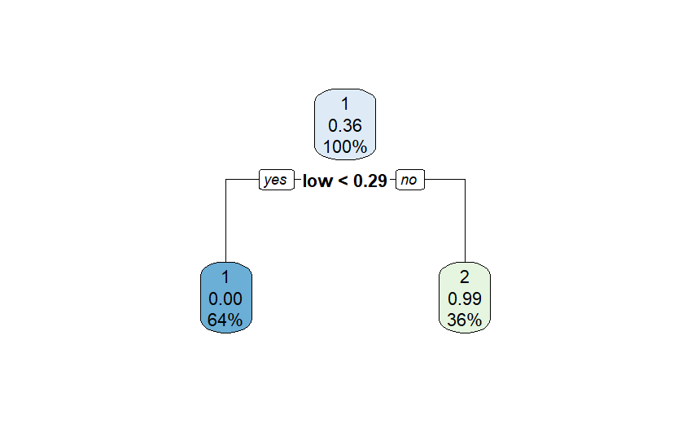

```r
library(rpart.plot)
rpart.plot(dataset.cart)
```

# Checking the order of variable importance

```r
dataset.cart$variable.importance
```

```
       low       open       high     volume
453.050014 446.826799 445.582156   2.489286
```

```r
pred.tree = predict(dataset.cart, testData, type = "class")

table(pred.tree,testData$close)
```

```
pred.tree   1   2
        1 167   2
        2   1  85
```

```r
# 5.Use the constructed model to predict the class labels of test data:
testPred <- predict(dataset_ctree, newdata = testData)
result<-table(testPred, testData$close)
result
```

```
testPred   1   2
       1 167   3
       2   1  84
```

```r
# Evaluate the model and create confusion matrix
install.packages("caret")
```

```
Error in install.packages : Updating loaded packages
```

```r
install.packages('e1071', dependencies=TRUE)
```

```
Error in install.packages : Updating loaded packages
```

```r
library(e1071)
library(caret)

co_result <- confusionMatrix(result)

print(co_result)
```

```
Confusion Matrix and Statistics


testPred   1   2
       1 167   3
       2   1  84

               Accuracy : 0.9843
                 95% CI : (0.9603, 0.9957)
    No Information Rate : 0.6588
    P-Value [Acc > NIR] : <2e-16

                  Kappa : 0.9649

 Mcnemar's Test P-Value : 0.6171

            Sensitivity : 0.9940
            Specificity : 0.9655
         Pos Pred Value : 0.9824
         Neg Pred Value : 0.9882
             Prevalence : 0.6588
         Detection Rate : 0.6549
   Detection Prevalence : 0.6667
      Balanced Accuracy : 0.9798

       'Positive' Class : 1
```

```r
sensitivity(as.table(co_result))
```

```
[1] 0.9940476
```

```r
specificity(as.table(co_result))
```

```
[1] 0.9655172
```

```r
acc <- co_result$overall["Accuracy"]
acc
```

```
 Accuracy
0.9843137
```

3. Building the Tree using Gain ratio(C5)

```r
install.packages("caret")
```

```
Error in install.packages : Updating loaded packages
```

```r
install.packages("C50")
```

```
Error in install.packages : Updating loaded packages
```

```r
install.packages("printr")
```

```
Error in install.packages : Updating loaded packages
```

```r
library(C50)
library(printr)
library(caret)
#train using the trainData and create the c5.0 gain ratio tree
CloseTree <- C5.0(myFormula, data=trainData)
summary(CloseTree)
```

```
Call:
C5.0.formula(formula = myFormula, data = trainData)


C5.0 [Release 2.07 GPL Edition]     Mon Nov 13 20:59:39 2023
-------------------------------

Class specified by attribute `outcome'

Read 1002 cases (5 attributes) from undefined.data

Decision tree:

low <= 0.294798: 1 (638/2)
low > 0.294798: 2 (364/3)


Evaluation on training data (1002 cases):

        Decision Tree
      ----------------
      Size      Errors

         2    5( 0.5%)   <<


       (a)   (b)    <-classified as
      ----  ----
       636     3    (a): class 1
         2   361    (b): class 2


    Attribute usage:

    100.00% low


Time: 0.0 secs
```

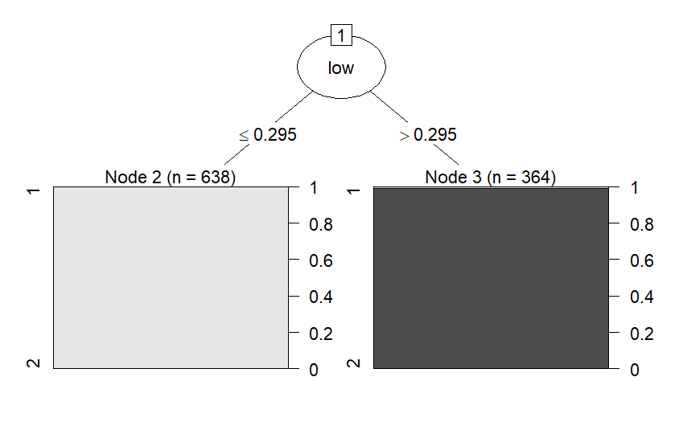

```r
plot(CloseTree)
```

the Training(70%) and Testing(30%) has sensitivity = 0.9959016 specificity = 0.9685039 Accuracy = 0.9865229

the Training(60%) and Testing(40%) has sensitivity = 0.9969512 specificity = 0.9710983 Accuracy = 0.988024

the Training(80%) and Testing(20%) has sensitivity = 0.9940476 specificity = 0.9655172 Accuracy = 0.9843137

Clustring

```r
# prepreocessing
#Data types should be transformed into numeric types before clustering.
dataset<-dataset[,3:11]
dataset <- scale(dataset)
View(dataset)
```

Apply k-means clustering for different values of K

```r
# k-means clustering to find 4 clusters
#set a seed for random number generation  to make the results reproducible
set.seed(8953)
kmeans.result <- kmeans(dataset, 4)

# print the clustering result
print(kmeans.result)
```

```
K-means clustering with 4 clusters of sizes 134, 150, 503, 470

Cluster means:
        high        low       open     volume   adjClose    adjHigh
1 -0.2629312 -0.3135366 -0.2805957  2.2141282 -0.2906810 -0.2629312
2  2.1673097  2.1726113  2.1685156 -0.1861980  2.1701761  2.1673097
3  0.1726777  0.1765031  0.1740847 -0.2310522  0.1746725  0.1726777
4 -0.8015331 -0.7928912 -0.7983875 -0.3245621 -0.7966711 -0.8015331
      adjLow    adjOpen  adjVolume
1 -0.3135366 -0.2805957  2.2141282
2  2.1726112  2.1685156 -0.1861980
3  0.1765032  0.1740847 -0.2310522
4 -0.7928912 -0.7983875 -0.3245621

Clustering vector:
```

[output cut: 155 more lines]

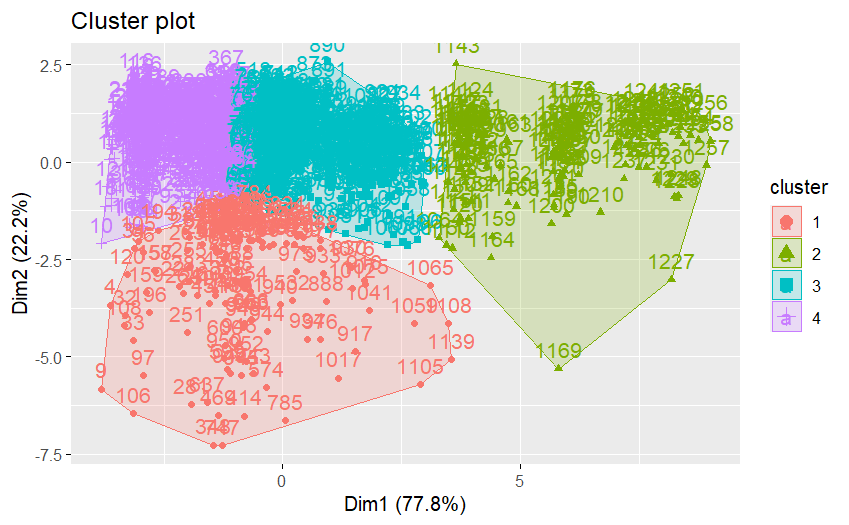

```r
# visualize clustering
#install.packages("factoextra")
library(factoextra)
fviz_cluster(kmeans.result, data = dataset)
```

```r
# run k-means clustering to find 3 clusters
#set a seed for random number generation  to make the results reproducible
set.seed(8953)
kmeans.result <- kmeans(dataset, 3)

# print the clustering result
print(kmeans.result)
```

```
K-means clustering with 3 clusters of sizes 401, 147, 709

Cluster means:
        high        low       open     volume   adjClose    adjHigh
1  0.2539963  0.2350572  0.2461952  0.6946321  0.2440646  0.2539963
2  2.1841383  2.1905594  2.1867825 -0.2193913  2.1868820  2.1841383
3 -0.5965033 -0.5871229 -0.5926393 -0.3473864 -0.5914550 -0.5965033
      adjLow    adjOpen  adjVolume
1  0.2350572  0.2461952  0.6946321
2  2.1905594  2.1867825 -0.2193913
3 -0.5871229 -0.5926393 -0.3473864

Clustering vector:
   1    2    3    4    5    6    7    8    9   10   11   12   13   14
   3    3    3    3    3    3    3    3    1    3    3    3    3    3
```

[output cut: 153 more lines]

```r
#4- visualize clustering
#install.packages("factoextra")
library(factoextra)
fviz_cluster(kmeans.result, data = dataset)
```

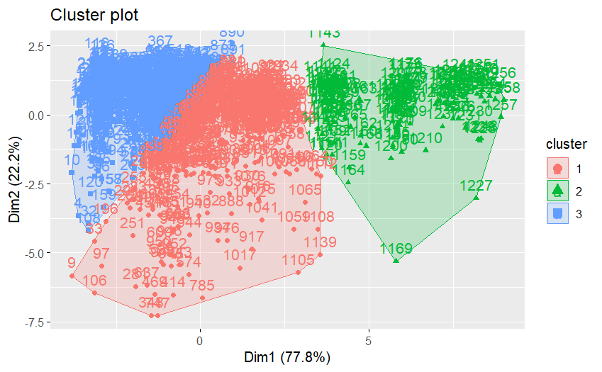

```r
#4- visualize clustering
#install.packages("factoextra")
library(factoextra)
fviz_cluster(kmeans.result, data = dataset)
```

```r
# run k-means clustering to find 2 clusters
#set a seed for random number generation  to make the results reproducible
set.seed(8953)
kmeans.result <- kmeans(dataset, 2)

# print the clustering result
print(kmeans.result)
```

```
K-means clustering with 2 clusters of sizes 966, 291

Cluster means:
        high        low       open       volume   adjClose    adjHigh
1 -0.4481444 -0.4474014 -0.4477879 -0.006969685 -0.4475681 -0.4481444
2  1.4876545  1.4851882  1.4864711  0.023136481  1.4857416  1.4876545
      adjLow    adjOpen    adjVolume
1 -0.4474014 -0.4477879 -0.006969685
2  1.4851882  1.4864711  0.023136481

Clustering vector:
   1    2    3    4    5    6    7    8    9   10   11   12   13   14
   1    1    1    1    1    1    1    1    1    1    1    1    1    1
  15   16   17   18   19   20   21   22   23   24   25   26   27   28
   1    1    1    1    1    1    1    1    1    1    1    1    1    1
```

[output cut: 151 more lines]

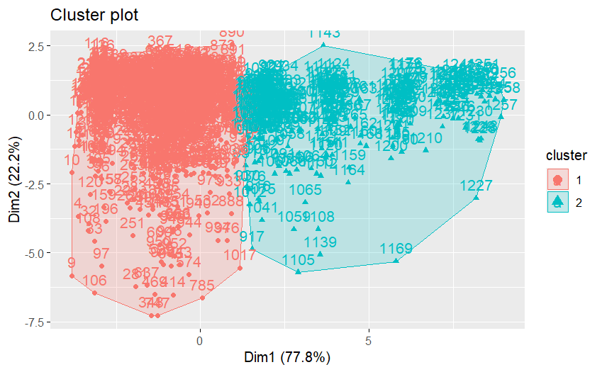

```r
#4- visualize clustering
#install.packages("factoextra")
library(factoextra)
fviz_cluster(kmeans.result, data = dataset)
```

```r
install.packages("fpc")
```

```
Error in install.packages : Updating loaded packages
```

```r
library(fpc)
#kmeansruns() : It calls  kmeans() to perform  k-means clustering
#It initializes the k-means algorithm several times with random points from the data set as means.
#It estimates the number of clusters by index or average silhouette width
kmeansruns.result <- kmeansruns(dataset)
kmeansruns.result
```

```
K-means clustering with 5 clusters of sizes 319, 95, 498, 132, 213

Cluster means:
        high        low       open      volume   adjClose    adjHigh
1 -0.9807559 -0.9680768 -0.9756695 -0.35231191 -0.9735707 -0.9807559
2  2.5784542  2.5908436  2.5851856 -0.25281895  2.5844001  2.5784542
3 -0.1716476 -0.1649013 -0.1685021 -0.32889807 -0.1682687 -0.1716476
4 -0.2909193 -0.3405884 -0.3084413  2.21036082 -0.3182142 -0.2909193
5  0.9004218  0.8909150  0.8933064  0.03957237  0.8960241  0.9004218
      adjLow    adjOpen   adjVolume
1 -0.9680768 -0.9756695 -0.35231191
2  2.5908435  2.5851856 -0.25281895
3 -0.1649014 -0.1685021 -0.32889807
4 -0.3405884 -0.3084413  2.21036082
5  0.8909150  0.8933064  0.03957237
```

[output cut: 157 more lines]

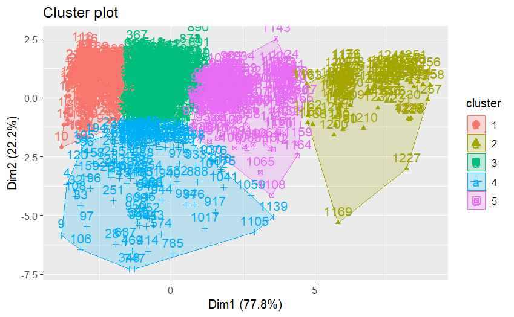

```r
fviz_cluster(kmeansruns.result, data = dataset)
```

k-mediods clustering with PAM

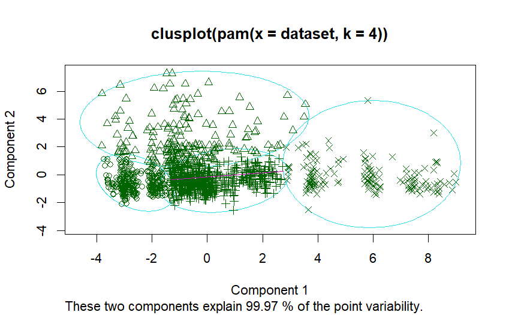

[figure not shown]

```r
#install.packages("cluster")
library(cluster)
# group into 4 clusters
pam.result <- pam(dataset, 4)
plot(pam.result)
```

Hierarchical Clustering

```r
##----Hierarchical Clustering of the Data-----##
set.seed(2835)
# draw a sample of 40 records from the dataset data, so that the clustering plot will not be over crowded
idx <- sample(1:dim(dataset)[1], 40)
dataset2 <- dataset[idx, ]
## hiercrchical clustering
library(factoextra)
hc.cut <- hcut(dataset2, k = 2, hc_method = "complete") # Computes Hierarchical Clustering and Cut the Tree
```

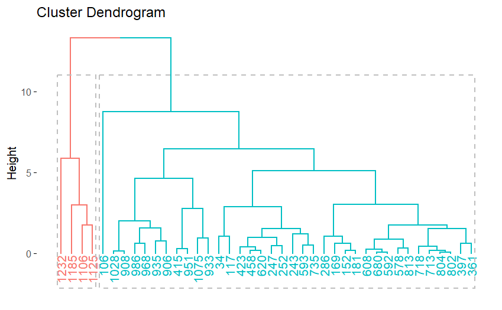

```r
# Visualize dendrogram
fviz_dend(hc.cut,rect = TRUE)  #logical value specifying whether to add a rectangle around groups.
```

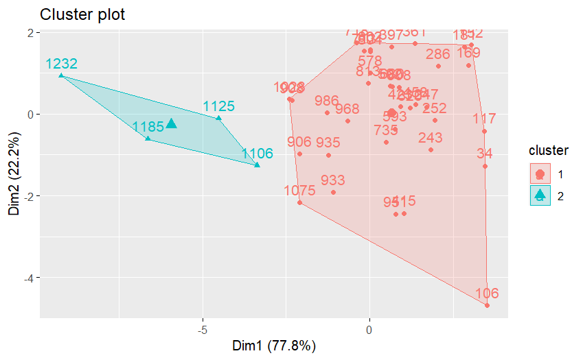

```r
# Visualize cluster
fviz_cluster(hc.cut, ellipse.type = "convex") # Character specifying frame type. Possible values are 'convex', 'confidence' etc
```

Validation

```r
#average silhouette for each clusters
library(cluster)
avg_sil <- silhouette(kmeans.result$cluster,dist(dataset)) #a dissimilarity object inheriting from class dist or coercible to one. If not specified, dmatrix must be.
fviz_silhouette(avg_sil)#k-means clustering with estimating k and initializations
```

|  | cluster | size | ave.sil.width |
| --- | --- | --- | --- |
| 1 | 1 | 966 | 0.57 |
| 2 | 2 | 291 | 0.39 |

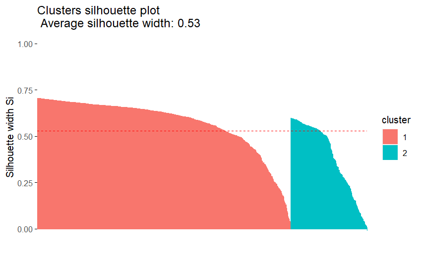

```r
NA
```

# define function to compute average silhouette for k clusters using silhouette()

```r
silhouette_score <- function(k){
  km <- kmeans(USArrests, centers = k,nstart=25) # if centers is a number, how many random sets should be chosen?
  ss <- silhouette(km$cluster, dist(USArrests))
  sil<- mean(ss[, 3])
  return(sil)
}
```

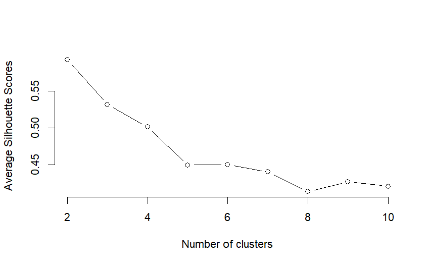

```r
# k cluster range from 2 to 10
k <- 2:10
##  call  function fore k value
avg_sil <- sapply(k, silhouette_score)  ##Apply a Function over a List or Vector
plot(k, type='b', avg_sil, xlab='Number of clusters', ylab='Average Silhouette Scores', frame=FALSE)
```

silhouette method

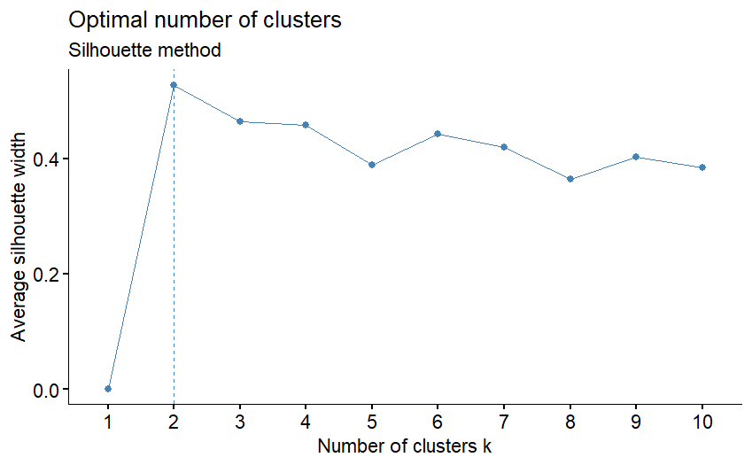

```r
#install.packages("NbClust")
library(NbClust)
#a)fviz_nbclust() with silhouette method using library(factoextra)
fviz_nbclust(dataset, kmeans, method = "silhouette")+
  labs(subtitle = "Silhouette method")
```

```r
#b) NbClust validation
fres.nbclust <- NbClust(dataset, distance="euclidean", min.nc = 2, max.nc = 10, method="kmeans", index="all")
```

[output not shown]

```r
# Elbow method for determining the optimal number of clusters (k-means)
wss <- numeric(length = 10)
for (k in 1:10) {
  kmeans_model <- kmeans(dataset, centers = k, nstart = 10)
  wss[k] <- sum(kmeans_model$close)
}
```

```r
# Extract the total within-cluster sum of squares (TWSS)
twss <- sum(kmeans.result$withinss)
# Print the TWSS
cat(paste("Total Within-Cluster Sum of Squares (TWSS):", twss, "\n"))
```

```
Total Within-Cluster Sum of Squares (TWSS): 5447.8141294376
```

```r
# Evaluate BCubed precision and recall for k-medoids
# Install and load required libraries
library(caret)
library(ggplot2)
library(lattice)


# Assuming you have true labels and predicted labels
true_labels <- c(1, 1, 1, 0, 0, 1, 0, 1, 0, 1)
predicted_labels <- c(1, 0, 1, 0, 0, 1, 0, 1, 1, 1)

# Create a confusion matrix
conf_matrix <- confusionMatrix(factor(predicted_labels), factor(true_labels))

# Extract recall from the confusion matrix
recall <- conf_matrix$byClass["Sensitivity"]

# Print the result
cat(paste("Recall:", recall, "\n"))
```

```
Recall: 0.75
```